# Exam 1

## Exam 1

#### Metainformation

1. | Tag | Value |
   | --- | --- |
   | `file` | Inferential_Statistics_vufsw-intercept-0095-nl_vufsw-intercept-0095-nl |
   | `name` | vufsw-intercept-0095-nl |
   | `section` | inferential statistics/regression/intercept |
   | `type` | schoice |
   | `solution` | FALSE, FALSE, TRUE, FALSE, FALSE, FALSE, FALSE, FALSE |
   | `Type` | interpretating output |
   | `Program` | NA |
   | `Language` | dutch |
   | `Level` | statistical literacy |

#### Question

   Een onderzoeker voert een enkelvoudige regressie-analyse uit met de mate van vertrouwen in de politie (variabele: “**Rapportcijfer_politie**”) als afhankelijke variabele en de dummy variabele “**Migrantieachtergrond**” als onafhankelijke variabele.  
   Wat is het intercept (de constante) in dit model? En wat is de betekenis van dit getal?

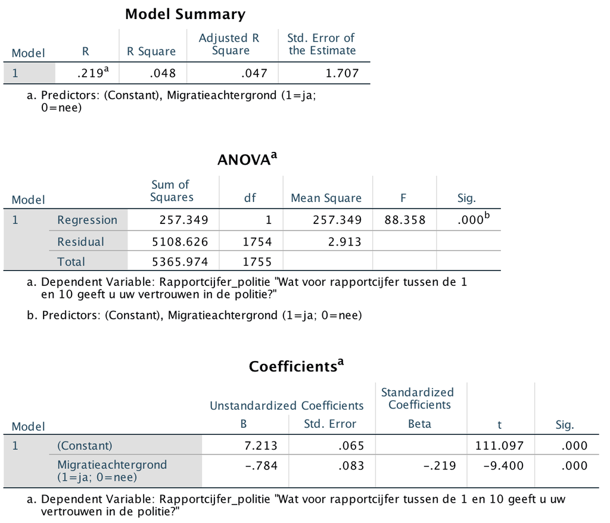

   1. **FALSE:** Het intercept is ,065. Dit is de gemiddelde mate van vertrouwen in de politie van mensen *zonder* een migratieachtergrond.
   2. **FALSE:** Het intercept is ,065. Dit is de gemiddelde mate van vertrouwen in de politie van mensen *met* een migratieachtergrond.
   3. **TRUE:** Het intercept is 7,213. Dit is de gemiddelde mate van vertrouwen in de politie van mensen *zonder* een migratieachtergrond.
   4. **FALSE:** Het intercept is 7,213. Dit is de gemiddelde mate van vertrouwen in de politie van mensen *met* een migratieachtergrond.
   5. **FALSE:** Het intercept is ,083. Dit is de gemiddelde mate van vertrouwen in de politie van mensen *zonder* een migratieachtergrond.
   6. **FALSE:** Het intercept is ,083. Dit is de gemiddelde mate van vertrouwen in de politie van mensen *met* een migratieachtergrond.
   7. **FALSE:** Het intercept is -,784. Dit is de gemiddelde mate van vertrouwen in de politie van mensen *zonder* een migratieachtergrond.
   8. **FALSE:** Het intercept is -,784. Dit is de gemiddelde mate van vertrouwen in de politie van mensen *met* een migratieachtergrond.

#### Solution

   Language  
   Nederlands

   Levels of Difficulty  
   Easy

   M&T Basics of quantitative research  
   Basics of quantitative research

   M&T BIS  
   Default value
   1. False
   2. False
   3. True
   4. False
   5. False
   6. False
   7. False
   8. False